# Week 4: Cluster Analysis, Part 1

Xuan Pham

November 12, 2018

# Getting Started

The packages you will need to install for the next two weeks are **clusterSim**, **cluster**, **fpc**, **klaR**, **clusMixType**, and **tidyverse**.

Note: The clusterSim package may not load successfully without a dependent package called **genefilter**. If you receive this error, please run the following code chunk below and then load clusterSim again.

```r
#if (!requireNamespace("BiocManager", quietly = TRUE))
#    install.packages("BiocManager")
#BiocManager::install("genefilter", version = "3.8")
```

```r
library(cluster)
library(clusterSim)
library(fpc)
library(klaR)
library(clustMixType)
library(tidyverse)
options(scipen = 999)
```

## Cluster Analysis

In the previous weeks, we have looked at several supervised learning methods: knn, Naive Bayes, logistic regression, and decision trees. Unsupervised learning is ‘unsupervised’ because we do not have a target (outcome variable).

Clustering is meant to be used for “knowledge discovery” instead of “prediction.” The basis of clustering is what sociologists call “homophily”-or birds of the same feather flock together. The goal of clustering is to find groups, or clusters, in a data set. We want to partition our dataset so that observations within each group are similar to each other while observations in different groups are different from each other.

There are many clustering algorithms, which are based on many different approaches of grouping data points. We will split this week’s discussion into two parts: 1) numeric data and 2) categorical and mixed data types.

## Clustering Numeric Data

We will discuss two approaches to clustering numeric data: 1) partitioning and 2) hierarchical. The partitioning approach divides the dataset into multiple partitions. The hierarchical approach disaggregates the dataset into a tree structure (similar to decision trees). We will leave the hierarchical discussion for next week.

We will look at two partitioning methods: k-means and k-medoids.

### Business Problem

What interesting things can we learn from online postings of 30,000 teenagers on a social media site? (Notice that we have no target/outcome variable. We am simply looking for interesting patterns.)

We will use the Teen Market Segmentation dataset from Chapter 9 in Lantz (2013). According to Lantz, the dataset is a random sample of 30,000 U.S. high school students who had profiles on a social networking service (SNS) in 2006. The full text of the SNS profiles were downloaded. Each teen’s gender, age, and number of SNS friends were recorded. From the top 500 words that appeared across all SNS profiles, a smaller list of 36 words were chosen to represent five categories of interest: extracurricular activities, fashion, religion, romance, and antisocial behavior (Lantz 2013, p. 279).

```r
teens<-read.csv("~/Dropbox/Fall_2018/BIA_6301/Week_4/snsdata.csv", header=TRUE, sep=",")

str(teens)
```

```
## 'data.frame':    30000 obs. of  40 variables:
##  $ gradyear    : int  2006 2006 2006 2006 2006 2006 2006 2006 2006 2006 ...
##  $ gender      : Factor w/ 2 levels "F","M": 2 1 2 1 NA 1 1 2 1 1 ...
##  $ age         : num  19 18.8 18.3 18.9 19 ...
##  $ friends     : int  7 0 69 0 10 142 72 17 52 39 ...
##  $ basketball  : int  0 0 0 0 0 0 0 0 0 0 ...
##  $ football    : int  0 1 1 0 0 0 0 0 0 0 ...
##  $ soccer      : int  0 0 0 0 0 0 0 0 0 0 ...
##  $ softball    : int  0 0 0 0 0 0 0 1 0 0 ...
##  $ volleyball  : int  0 0 0 0 0 0 0 0 0 0 ...
##  $ swimming    : int  0 0 0 0 0 0 0 0 0 0 ...
##  $ cheerleading: int  0 0 0 0 0 0 0 0 0 0 ...
##  $ baseball    : int  0 0 0 0 0 0 0 0 0 0 ...
##  $ tennis      : int  0 0 0 0 0 0 0 0 0 0 ...
##  $ sports      : int  0 0 0 0 0 0 0 0 0 0 ...
```

[output cut: 26 more lines]

#### Exploratory Data Analysis

```r
summary(teens)
```

```
##     gradyear     gender           age             friends
##  Min.   :2006   F   :22054   Min.   :  3.086   Min.   :  0.00
##  1st Qu.:2007   M   : 5222   1st Qu.: 16.312   1st Qu.:  3.00
##  Median :2008   NA's: 2724   Median : 17.287   Median : 20.00
##  Mean   :2008                Mean   : 17.994   Mean   : 30.18
##  3rd Qu.:2008                3rd Qu.: 18.259   3rd Qu.: 44.00
##  Max.   :2009                Max.   :106.927   Max.   :830.00
##                              NA's   :5086
##    basketball         football           soccer           softball
##  Min.   : 0.0000   Min.   : 0.0000   Min.   : 0.0000   Min.   : 0.0000
##  1st Qu.: 0.0000   1st Qu.: 0.0000   1st Qu.: 0.0000   1st Qu.: 0.0000
##  Median : 0.0000   Median : 0.0000   Median : 0.0000   Median : 0.0000
##  Mean   : 0.2673   Mean   : 0.2523   Mean   : 0.2228   Mean   : 0.1612
##  3rd Qu.: 0.0000   3rd Qu.: 0.0000   3rd Qu.: 0.0000   3rd Qu.: 0.0000
##  Max.   :24.0000   Max.   :15.0000   Max.   :27.0000   Max.   :17.0000
##
##    volleyball         swimming        cheerleading       baseball
##  Min.   : 0.0000   Min.   : 0.0000   Min.   :0.0000   Min.   : 0.0000
##  1st Qu.: 0.0000   1st Qu.: 0.0000   1st Qu.:0.0000   1st Qu.: 0.0000
##  Median : 0.0000   Median : 0.0000   Median :0.0000   Median : 0.0000
##  Mean   : 0.1431   Mean   : 0.1344   Mean   :0.1066   Mean   : 0.1049
##  3rd Qu.: 0.0000   3rd Qu.: 0.0000   3rd Qu.:0.0000   3rd Qu.: 0.0000
##  Max.   :14.0000   Max.   :31.0000   Max.   :9.0000   Max.   :16.0000
##
##      tennis             sports           cute              sex
##  Min.   : 0.00000   Min.   : 0.00   Min.   : 0.0000   Min.   :  0.0000
##  1st Qu.: 0.00000   1st Qu.: 0.00   1st Qu.: 0.0000   1st Qu.:  0.0000
##  Median : 0.00000   Median : 0.00   Median : 0.0000   Median :  0.0000
##  Mean   : 0.08733   Mean   : 0.14   Mean   : 0.3229   Mean   :  0.2094
##  3rd Qu.: 0.00000   3rd Qu.: 0.00   3rd Qu.: 0.0000   3rd Qu.:  0.0000
##  Max.   :15.00000   Max.   :12.00   Max.   :18.0000   Max.   :114.0000
##
##       sexy              hot              kissed            dance
##  Min.   : 0.0000   Min.   : 0.0000   Min.   : 0.0000   Min.   : 0.0000
##  1st Qu.: 0.0000   1st Qu.: 0.0000   1st Qu.: 0.0000   1st Qu.: 0.0000
##  Median : 0.0000   Median : 0.0000   Median : 0.0000   Median : 0.0000
##  Mean   : 0.1412   Mean   : 0.1266   Mean   : 0.1032   Mean   : 0.4252
##  3rd Qu.: 0.0000   3rd Qu.: 0.0000   3rd Qu.: 0.0000   3rd Qu.: 0.0000
##  Max.   :18.0000   Max.   :10.0000   Max.   :26.0000   Max.   :30.0000
##
```

[output cut: 25 more lines]

```
##  Min.   : 0.000   Min.   :0.0000   Min.   :0.00000   Min.   :0.00000
##  1st Qu.: 0.000   1st Qu.:0.0000   1st Qu.:0.00000   1st Qu.:0.00000
##  Median : 0.000   Median :0.0000   Median :0.00000   Median :0.00000
##  Mean   : 0.353   Mean   :0.1485   Mean   :0.06987   Mean   :0.05117
##  3rd Qu.: 1.000   3rd Qu.:0.0000   3rd Qu.:0.00000   3rd Qu.:0.00000
##  Max.   :11.000   Max.   :8.0000   Max.   :9.00000   Max.   :8.00000
##
##       die              death             drunk             drugs
##  Min.   : 0.0000   Min.   : 0.0000   Min.   :0.00000   Min.   : 0.00000
##  1st Qu.: 0.0000   1st Qu.: 0.0000   1st Qu.:0.00000   1st Qu.: 0.00000
##  Median : 0.0000   Median : 0.0000   Median :0.00000   Median : 0.00000
##  Mean   : 0.1841   Mean   : 0.1142   Mean   :0.08797   Mean   : 0.06043
##  3rd Qu.: 0.0000   3rd Qu.: 0.0000   3rd Qu.:0.00000   3rd Qu.: 0.00000
##  Max.   :22.0000   Max.   :14.0000   Max.   :8.00000   Max.   :16.00000
##
```

First, notice the ranges for the values for each variable. Next, notice the number of missing values for some variables.

#### Problematic Data Values

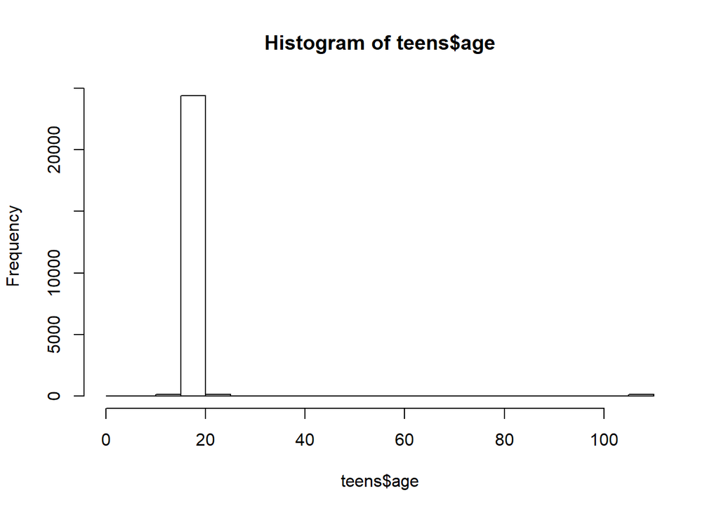

```r
hist(teens$age)
```

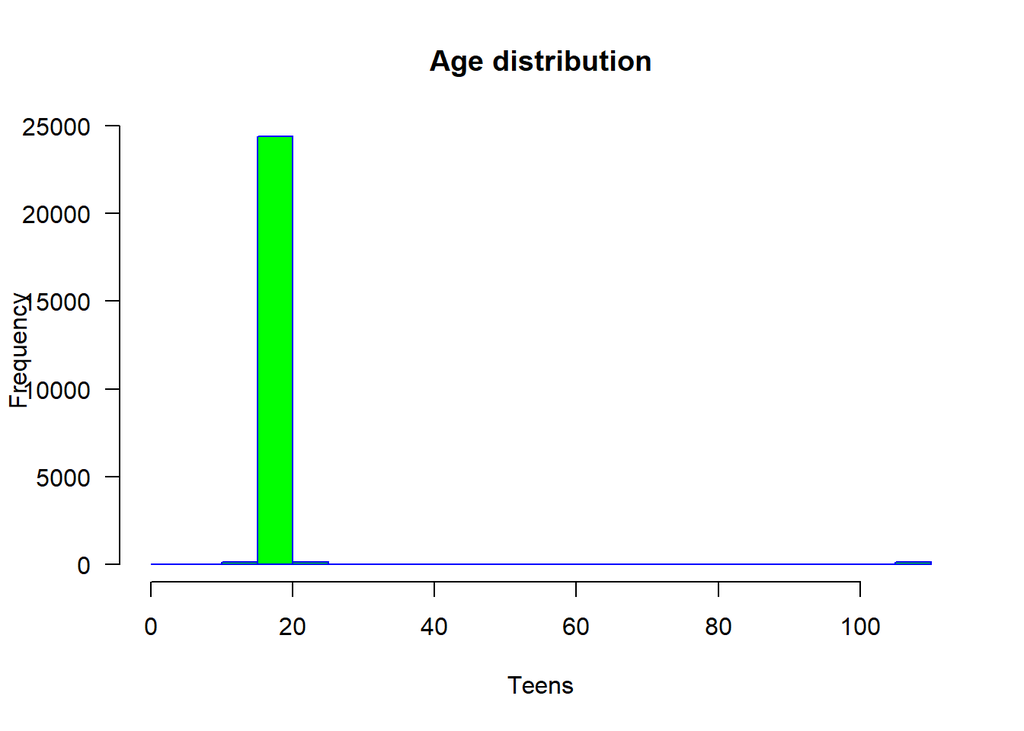

```r
#fancier one
hist(teens$age,
     main="Age distribution",
     xlab="Teens",
     border="blue",
     col="green",
     las=1)
```

The age variable has a very large range. Minimum age is 3.086. Maximum age is 106.927. There are also 5,086 missing values.

Great Rblogger post on histograms: https://www.r-bloggers.com/how-to-make-a-histogram-with-basic-r/

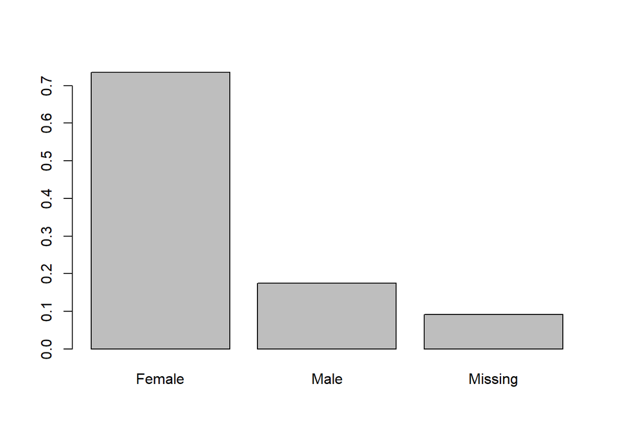

```r
barplot(prop.table(table(teens$gender, useNA = "ifany")), names.arg=c("Female", "Male","Missing"))
```

```r
# why can't we use the hist command with gender?
```

The gender variable has 2,724 missing values. We should also note the gender distribution: 22,054 females and 5,222 males.

Let’s see the percentage of missing values for our variables:

```r
#calculate the proportion of missing values
pMiss <- function(x){sum(is.na(x))/length(x)*100}
apply(teens,2,pMiss)
```

```
##     gradyear       gender          age      friends   basketball
##      0.00000      9.08000     16.95333      0.00000      0.00000
##     football       soccer     softball   volleyball     swimming
##      0.00000      0.00000      0.00000      0.00000      0.00000
## cheerleading     baseball       tennis       sports         cute
##      0.00000      0.00000      0.00000      0.00000      0.00000
##          sex         sexy          hot       kissed        dance
##      0.00000      0.00000      0.00000      0.00000      0.00000
##         band     marching        music         rock          god
##      0.00000      0.00000      0.00000      0.00000      0.00000
##       church        jesus        bible         hair        dress
##      0.00000      0.00000      0.00000      0.00000      0.00000
##       blonde         mall     shopping      clothes    hollister
##      0.00000      0.00000      0.00000      0.00000      0.00000
##  abercrombie          die        death        drunk        drugs
##      0.00000      0.00000      0.00000      0.00000      0.00000
```

Source: Code chunk above from [this](https://www.r-bloggers.com/imputing-missing-data-with-r-mice-package/) entry from Rblogger.

16% of data values for age is missing. 9% of data values for gender is missing. If we compound the fact that some people did not report their true age, this variable is our “bigger” problem. Let’s tackle it first.

#### One Problem at a Time: Recoding Age via Imputation

First, we need to make an assumption: **Teenagers are between the age of 13 and 20.** Anyone who does not have a reported age in this assumed range will be recoded as “NA.”

```r
teens$age <- ifelse(teens$age >= 13 & teens$age < 20,
                     teens$age, NA)
```

To handle the missing age values, we will use imputation. It is common to impute missing values with expected values (i.e. what we expect those values to be). Mean and median imputations are common techniques. If the distribution is normal, we use mean imputation. If the distribution is skewed, we use median imputation.

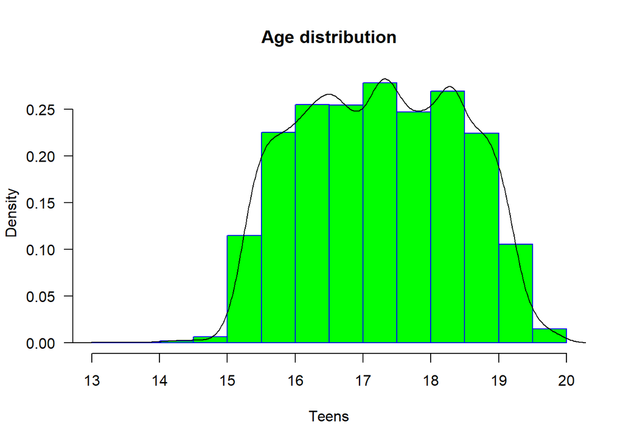

```r
hist(na.omit(teens$age),
     main="Age distribution",
     xlab="Teens",
     border="blue",
     col="green",
     las=1,
     prob = TRUE)
lines(density(na.omit(teens$age)))
```

The distribution looks pretty normal. Let’s proceed with mean imputation.

```r
# Finding the mean age by cohort
mean(teens$age) # Doesn't work b/c of NA
```

```
## [1] NA
```

```r
mean(teens$age, na.rm = TRUE) #This tells R to ignore NA in calculating the mean.
```

```
## [1] 17.25243
```

```r
# Review age by cohort
aggregate(data = teens, age ~ gradyear, mean, na.rm = TRUE)
```

```
##   gradyear      age
## 1     2006 18.65586
## 2     2007 17.70617
## 3     2008 16.76770
## 4     2009 15.81957
```

```r
# Calculating the expected age for each person
# This creates a new variable called ave_age
ave_age <- ave(teens$age, teens$gradyear,
                 FUN = function(x) mean(x, na.rm = TRUE))



teens$age <- ifelse(is.na(teens$age), ave_age, teens$age)
#Removes the missing values and replaces with mean age.

# Check to make sure missing values are eliminated
summary(teens$age)
```

```
##    Min. 1st Qu.  Median    Mean 3rd Qu.    Max.
##   13.03   16.28   17.24   17.24   18.21   20.00
```

#### Second Problem: Missing Gender Values

We have three possible levels: female, male, and NA (no reported gender). We will create two dummy variables to handle the gender missing values: 1) female and 2) no_gender.

```r
teens$female <- ifelse(teens$gender == "F" &
                         !is.na(teens$gender), 1, 0)
#If female & not missing gender value = 1
#Else = 0 (this includes male & missing values)

teens$no_gender <- ifelse(is.na(teens$gender), 1, 0)
#If gender is unknown then no_gender = 1. This is how we extract out the "missing values" versus "male" from the previous dummy variable.

# Check our recoding work
table(teens$gender, useNA = "ifany") #We have 2,724 cases of unknown gender.
```

```
##
##     F     M  <NA>
## 22054  5222  2724
```

```r
table(teens$female, useNA = "ifany")
```

```
##
##     0     1
##  7946 22054
```

```r
table(teens$no_gender, useNA = "ifany") #We have 2,724 cases of unknown gender. This matches up with our count in the gender variable.
```

```
##
##     0     1
## 27276  2724
```

#### What Do We Want to Examine?

We want to cluster what these 30,000 teenagers talked about on their SNS profiles with regards to the five categories of interests: extracurricular activities, fashion, religion, romance, and antisocial behavior. Let’s just use their interests to form clusters.

```r
interests <- teens[5:40] #Take the 5th through the 40th variables into the model.
```

#### Let’s Talk Cluster Analysis

[Visualizing K-Means](https://www.naftaliharris.com/blog/visualizing-k-means-clustering/)

## Partitioning Approach

General process:

1. Choose the number of clusters (k)
2. Partition the dataset into k clusters so that the sum of squared distances is minimized between the data points (p) and some center point [c(i)] in each cluster.

Two questions naturally arise from above:

**Question 1**: How do we determine the center points?

**Answer**: We select a clustering algorithm. We will examine k-means and k-medoids.

**Question 2**: How do you measure the distance between the data points and center points?

**Answer**: We use either Euclidean (straight line) or Manhattan distance (city block).

#### K-Means Clustering

We will begin by building a cluster model with five clusters. There’s no right place to start. Just pick a k value that you think is most suitable and start.

Remember that in k-means, the starting centroids are randomly chosen.

**nstart** is the number of times the starting points are re-sampled. Think of it this way: R does clustering assignment for each data point 25 times and picks the center that have the lowest within cluster variation. The “best” centroids become the starting point by which kmeans will continue to iterate. Typically you can set nstart to between 20 and 25 to find the best overall random start. See Morissette & Chartier (2013) [paper](http://www.tqmp.org/Content/vol09-1/p015/p015.pdf) for explanations of the different kmeans algorithms. I recommend reviewing Table 5 in the paper for additional information on the various kmeans algorithm.

**iter.max** = maximum number of iterations before stopping (unless convergence is already achieved before max iterations).

**The default algorithm is Hartigan-Wong, which minimizes the within-cluster sum of squares.**

```r
set.seed(123)
teen_clusters_5 <- kmeans(interests, centers=5)
```

Let’s see what are the outputs from kmeans:

```r
names(teen_clusters_5)
```

```
## [1] "cluster"      "centers"      "totss"        "withinss"
## [5] "tot.withinss" "betweenss"    "size"         "iter"
## [9] "ifault"
```

Size: Number of people in each cluster. Cluster 3 has the most number of people. Follows by Clusters 5 & 1.

```r
teen_clusters_5$size
```

```
## [1]  4216  1538 18973   773  4500
```

Let’s see each row and its assigned cluster.

```r
teen_clusters_5$cluster[1:100] #limit it to the first 100 observations otherwise it will print out all 30K!
```

```
##   [1] 3 4 1 3 1 1 3 3 3 2 3 3 3 3 1 3 3 3 3 3 3 3 3 2 3 3 3 2 3 2 3 5 3 1 3
##  [36] 3 3 3 3 4 3 3 5 1 3 1 5 2 3 1 3 1 5 3 3 3 1 4 3 3 3 3 4 3 1 3 3 1 1 1
##  [71] 1 3 3 3 3 3 3 3 3 3 5 3 3 5 3 3 3 3 3 3 1 3 5 3 3 3 5 3 3 3
```

Let’s show the coordinates of the cluster centroids for the interest variables.

```r
teen_clusters_5$centers
```

```
##   basketball  football    soccer  softball volleyball   swimming
## 1  0.1883302 0.2326850 0.1209677 0.1034156 0.09582543 0.15417457
## 2  0.3185956 0.2964889 0.1462939 0.1579974 0.13524057 0.15669701
## 3  0.1282876 0.1536394 0.0829600 0.0764771 0.08090444 0.09007537
## 4  0.7968952 0.7102199 0.4954722 0.3635188 0.26908150 0.32341527
## 5  0.8191111 0.5928889 0.8868889 0.5388889 0.43088889 0.26266667
##   cheerleading   baseball     tennis     sports      cute        sex
## 1   0.06783681 0.09369070 0.10578748 0.14302657 0.2599620 0.18477230
## 2   0.15734720 0.08972692 0.08777633 0.15149545 0.4785436 0.18985696
## 3   0.06920361 0.07046856 0.06967796 0.08996996 0.1638117 0.08970642
## 4   0.29236740 0.38809832 0.16429495 0.62483829 0.9495472 3.40491591
## 5   0.25155556 0.21733333 0.13111111 0.26066667 0.8915556 0.19488889
##        sexy        hot     kissed     dance      band   marching     music
## 1 0.1425522 0.11835863 0.11480076 0.3394213 1.1892789 0.17314991 2.4305028
## 2 0.2067620 0.20221066 0.09947984 3.1105332 0.3498049 0.03706112 0.9174252
```

[output cut: 21 more lines]

```r
t(teen_clusters_5$centers) #transpose for ease of reading purpose
```

```
##                       1          2          3          4          5
## basketball   0.18833017 0.31859558 0.12828757 0.79689521 0.81911111
## football     0.23268501 0.29648895 0.15363938 0.71021992 0.59288889
## soccer       0.12096774 0.14629389 0.08296000 0.49547219 0.88688889
## softball     0.10341556 0.15799740 0.07647710 0.36351876 0.53888889
## volleyball   0.09582543 0.13524057 0.08090444 0.26908150 0.43088889
## swimming     0.15417457 0.15669701 0.09007537 0.32341527 0.26266667
## cheerleading 0.06783681 0.15734720 0.06920361 0.29236740 0.25155556
## baseball     0.09369070 0.08972692 0.07046856 0.38809832 0.21733333
## tennis       0.10578748 0.08777633 0.06967796 0.16429495 0.13111111
## sports       0.14302657 0.15149545 0.08996996 0.62483829 0.26066667
## cute         0.25996205 0.47854356 0.16381173 0.94954722 0.89155556
## sex          0.18477230 0.18985696 0.08970642 3.40491591 0.19488889
## sexy         0.14255218 0.20676203 0.10789016 0.51487710 0.19377778
## hot          0.11835863 0.20221066 0.08164233 0.34152652 0.26111111
## kissed       0.11480076 0.09947984 0.03895009 1.43596378 0.13555556
## dance        0.33942125 3.11053316 0.18916355 1.09443726 0.46777778
## band         1.18927894 0.34980494 0.10441153 0.85769728 0.17600000
## marching     0.17314991 0.03706112 0.01644442 0.06597671 0.01511111
## music        2.43050285 0.91742523 0.28292837 2.70245796 0.67111111
## rock         0.42955408 0.32509753 0.13698414 1.41009056 0.28888889
## god          0.40702087 3.09882965 0.23812787 0.94566624 0.49511111
## church       0.22770398 0.77113134 0.11864228 0.40362225 0.60800000
## jesus        0.11598672 0.58452536 0.06756970 0.14618370 0.12866667
## bible        0.02371917 0.12418726 0.01054130 0.03492885 0.02711111
## hair         0.32756167 0.51560468 0.15042429 4.47736093 0.93066667
## dress        0.12286528 0.24187256 0.06177199 0.37645537 0.21688889
## blonde       0.06499051 0.10078023 0.03868655 1.28978008 0.17955556
## mall         0.20208729 0.31144343 0.13603542 0.78395860 0.71177778
## shopping     0.32447818 0.49024707 0.19991567 0.67270375 0.92333333
## clothes      0.15085389 0.23732120 0.07452696 0.84346701 0.30844444
## hollister    0.04625237 0.07932380 0.04095293 0.28201811 0.17422222
## abercrombie  0.03130930 0.07022107 0.03025352 0.24450194 0.11822222
## die          0.21513283 0.35825748 0.12270068 0.95730918 0.22155556
## death        0.14136622 0.22041612 0.07884889 0.42432083 0.14844444
## drunk        0.08870968 0.12288687 0.05760818 0.57956016 0.11888889
## drugs        0.07068311 0.06306892 0.02529911 0.67917206 0.09177778
```

#### Visualizing the Clusters

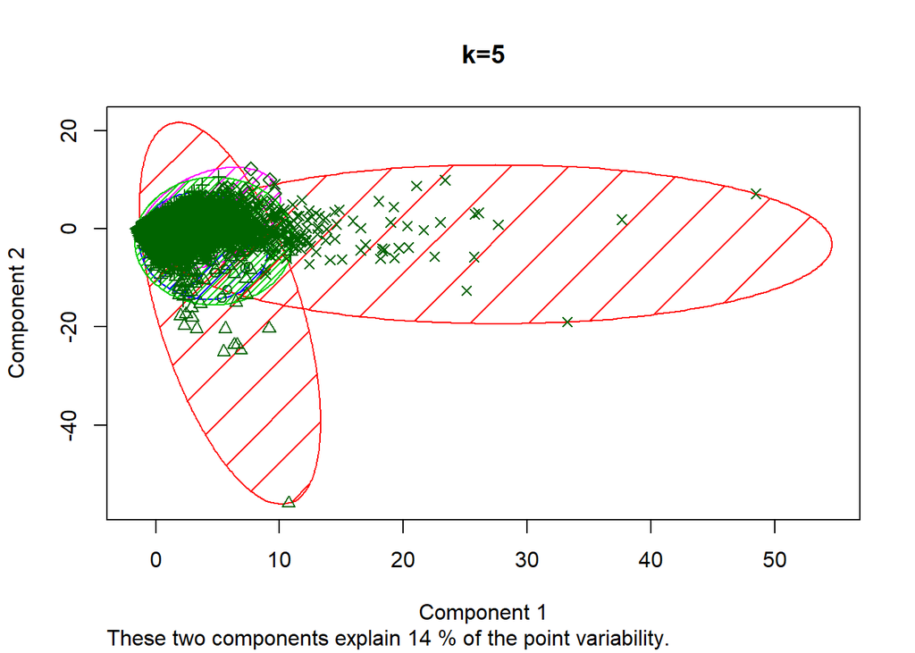

```r
library(fpc) #load this


clusplot(interests, teen_clusters_5$cluster, main = "k=5",color=TRUE, shade=TRUE, labels=0, lines=0) #creates visualization using principal components
```

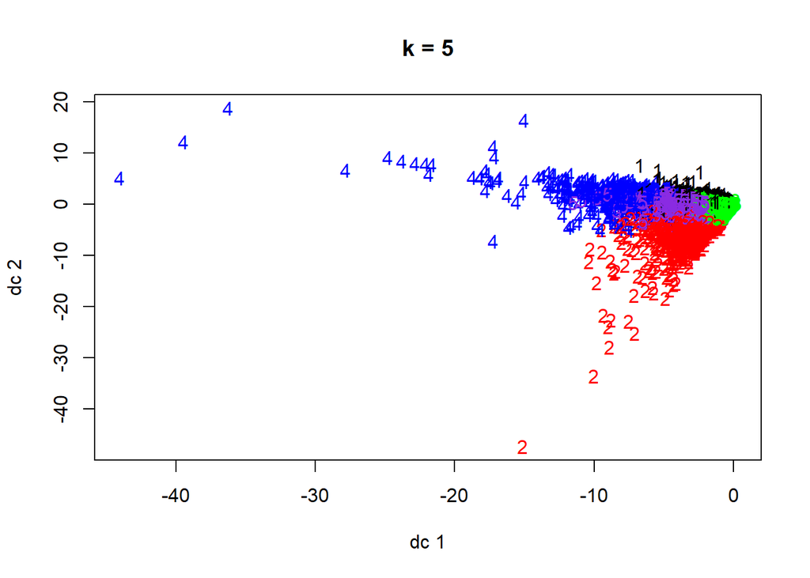

```r
plotcluster(interests, teen_clusters_5$cluster, main="k = 5") #creates a visualization using linear discriminants. Are there distinct groups?
```

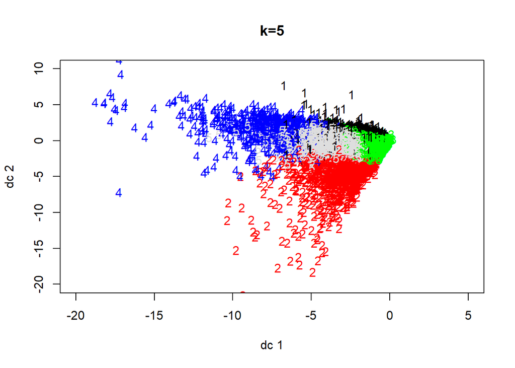

```r
#If all your data ends up in a corner and hard to read- change the lim for y and x:
#sometime you need to run it first with out the lims and then add them in and run again.
plotcluster(interests, teen_clusters_5$cluster, main="k=5", xlim=c(-20,5), ylim=c(-20,10))
```

#### What about k=4?

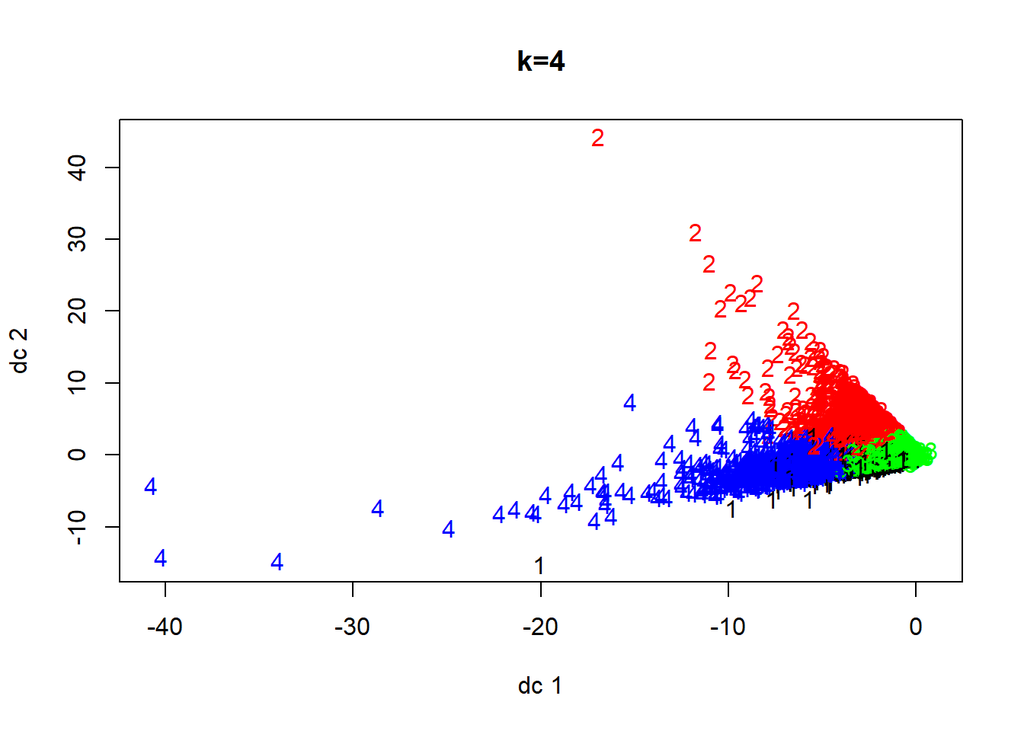

```r
set.seed(123)
teen_clusters_4 <- kmeans(interests, centers=4)
plotcluster(interests, teen_clusters_4$cluster, main="k=4")
```

#### What about k=3?

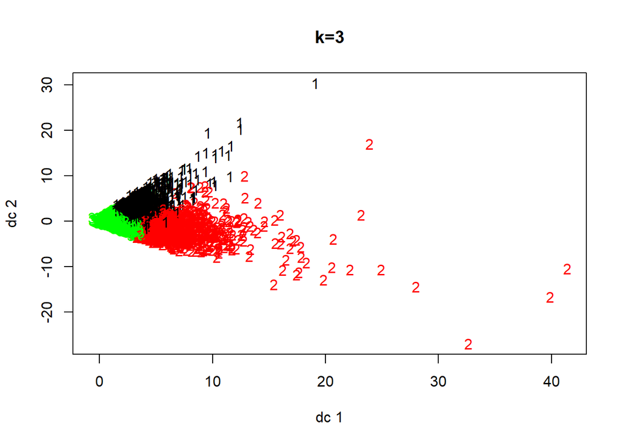

```r
set.seed(123)
teen_clusters_3 <- kmeans(interests, centers=3)
plotcluster(interests, teen_clusters_3$cluster, main="k=3")
```

#### Picking Among the K’s

##### A Digression on Sum of Squares

###### Within Sum of Squares (withinss)

We want our clusters to be “unique.” In another word, we want the sum of squares within each cluster to be small because it means the cluster is cohesive. As we stated earlier, the default algorithm in kmeans is Hartigan & Wong, which minimizes the withinss. What are the withinss for each cluster? Look at Clusters 3, 5, and 1 in particular. Which cluster has the largest withinss?

```r
teen_clusters_5$withinss
```

```
## [1]  78835.33  80153.80 102071.44 179006.65 128069.21
```

###### Between Sum of Squares (betweenss)

We want each cluster to be different from its neighboring clusters. The betweenss is the most useful when we want to compare among multiple kmeans models.

```r
teen_clusters_5$betweenss
```

```
## [1] 92856.37
```

###### Total Sum of Squares (totss)

totss = betweenss + withinss

```r
teen_clusters_5$totss
```

```
## [1] 660992.8
```

##### Method 1: Use the visualizations

Look at your cluster plots. Can you make a determination this way? This method is not reliable once you go beyond two variables. Use with caution!

##### Method 2: Examine the betweenss and withinss ratios!

We want the clusters to demonstrate both cohesion and separation. Cohesion is measured by minimizing the ratio of withinss/totalss. Separation is measured by maximizing the ratio of betweenss/totalss.

**Cluster Separation**

```r
clusters3<- teen_clusters_3$betweenss/teen_clusters_3$totss
clusters4<- teen_clusters_4$betweenss/teen_clusters_4$totss
clusters5<- teen_clusters_5$betweenss/teen_clusters_5$totss

betweenss.metric <- c(clusters3, clusters4, clusters5)
print(betweenss.metric) #Look for a ratio that is closer to 1.
```

```
## [1] 0.09368819 0.12094187 0.14048016
```

k=5 has the most separation.

**Cluster Cohesion**

```r
clusters3<- teen_clusters_3$tot.withinss/teen_clusters_3$totss
clusters4<- teen_clusters_4$tot.withinss/teen_clusters_4$totss
clusters5<- teen_clusters_5$tot.withinss/teen_clusters_5$totss

totwithinss.metric <- c(clusters3, clusters4, clusters5)
print(totwithinss.metric) #Looking for a ratio that is closer to 0.
```

```
## [1] 0.9063118 0.8790581 0.8595198
```

k=5 also has the most cluster cohesion.

###### The Elbow Plot

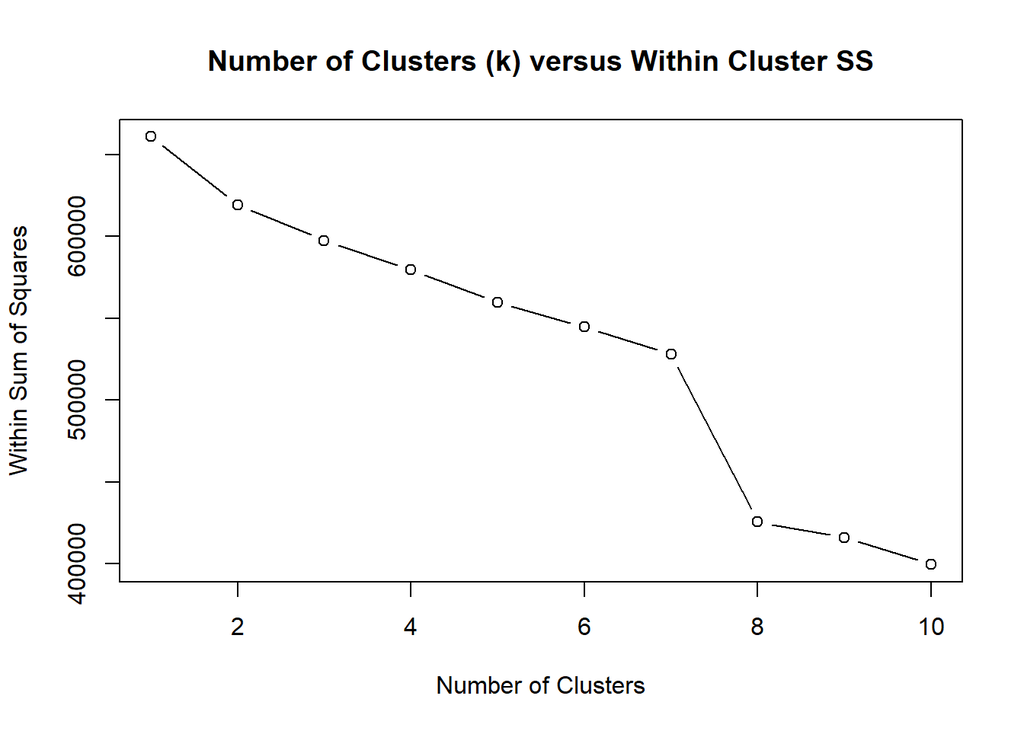

```r
#WithinSS
wss <- (nrow(interests)-1)*sum(apply(interests,2,var))
for (i in 2:10) wss[i] <- sum(kmeans(interests,
                                     centers=i)$withinss)
plot(1:10, wss, type="b", xlab="Number of Clusters",
     ylab="Within Sum of Squares", main = "Number of Clusters (k) versus Within Cluster SS")
```

Source: The above code chunk is from [here](http://stackoverflow.com/questions/15376075/cluster-analysis-in-r-determine-the-optimal-number-of-clusters)

##### Method 3: Using pseudo-F statistic

You should read https://github.com/cran/clusterSim/blob/master/inst/pdf/indexG1_details.pdf for **index.G1**.

Pseudo F-statistic = (between-cluster-sum-of-squares / (c-1)) / (within-cluster-sum-of-squares / (n-c))

with c beeing the number of clusters and n beeing the number of observations.

We are looking for a relative high psuedo F statistic.

```r
#library(clusterSim)
#?index.G1 #read the ../doc/indexG1_details.pdf

#a<-index.G1(interests, teen_clusters_3$cluster, centrotypes="centroids")
#b<-index.G1(interests, teen_clusters_4$cluster, centrotypes = "centroids")
#c<-index.G1(interests, teen_clusters_5$cluster, centrotypes = "centroids")
#pseudoF<-c(a,b,c)
#pseudoF
```

##### Method 4: Use Your Business Knowledge!

What is actionable? What is not? what do you know about your customers? Your data?

##### A Side Note: Trying an Automatic Pick

```r
library(fpc) #Requires this
teen_clusters_optimal<-kmeansruns(interests, krange=2:10) #finds the "best"" K between 2 and 10
teen_clusters_optimal$bestk
```

```
## [1] 4
```

##### Creating an Aggregate Profile for Our Clusters

To create “meaning” for our clusters, we need to give each cluster an “identity.”

```r
teen_clusters_5$size #Get the size of each cluster
```

```
## [1]  4216  1538 18973   773  4500
```

```r
Clusters_5<-data.frame(teen_clusters_5$centers) #Put the cluster centroids into a data frame
Clusters_5<-data.frame(t(teen_clusters_5$centers)) #Transpose for easier reading
```

We can sort the centroids for each cluster to see what the teens were writing on their profiles.

```r
Clusters_5[order(-Clusters_5$X1), ]
```

```
##                      X1         X2         X3         X4         X5
## music        2.43050285 0.91742523 0.28292837 2.70245796 0.67111111
## band         1.18927894 0.34980494 0.10441153 0.85769728 0.17600000
## rock         0.42955408 0.32509753 0.13698414 1.41009056 0.28888889
## god          0.40702087 3.09882965 0.23812787 0.94566624 0.49511111
## dance        0.33942125 3.11053316 0.18916355 1.09443726 0.46777778
## hair         0.32756167 0.51560468 0.15042429 4.47736093 0.93066667
## shopping     0.32447818 0.49024707 0.19991567 0.67270375 0.92333333
## cute         0.25996205 0.47854356 0.16381173 0.94954722 0.89155556
## football     0.23268501 0.29648895 0.15363938 0.71021992 0.59288889
## church       0.22770398 0.77113134 0.11864228 0.40362225 0.60800000
## die          0.21513283 0.35825748 0.12270068 0.95730918 0.22155556
## mall         0.20208729 0.31144343 0.13603542 0.78395860 0.71177778
## basketball   0.18833017 0.31859558 0.12828757 0.79689521 0.81911111
## sex          0.18477230 0.18985696 0.08970642 3.40491591 0.19488889
## marching     0.17314991 0.03706112 0.01644442 0.06597671 0.01511111
## swimming     0.15417457 0.15669701 0.09007537 0.32341527 0.26266667
## clothes      0.15085389 0.23732120 0.07452696 0.84346701 0.30844444
## sports       0.14302657 0.15149545 0.08996996 0.62483829 0.26066667
## sexy         0.14255218 0.20676203 0.10789016 0.51487710 0.19377778
## death        0.14136622 0.22041612 0.07884889 0.42432083 0.14844444
## dress        0.12286528 0.24187256 0.06177199 0.37645537 0.21688889
## soccer       0.12096774 0.14629389 0.08296000 0.49547219 0.88688889
## hot          0.11835863 0.20221066 0.08164233 0.34152652 0.26111111
## jesus        0.11598672 0.58452536 0.06756970 0.14618370 0.12866667
## kissed       0.11480076 0.09947984 0.03895009 1.43596378 0.13555556
## tennis       0.10578748 0.08777633 0.06967796 0.16429495 0.13111111
## softball     0.10341556 0.15799740 0.07647710 0.36351876 0.53888889
## volleyball   0.09582543 0.13524057 0.08090444 0.26908150 0.43088889
## baseball     0.09369070 0.08972692 0.07046856 0.38809832 0.21733333
## drunk        0.08870968 0.12288687 0.05760818 0.57956016 0.11888889
## drugs        0.07068311 0.06306892 0.02529911 0.67917206 0.09177778
## cheerleading 0.06783681 0.15734720 0.06920361 0.29236740 0.25155556
## blonde       0.06499051 0.10078023 0.03868655 1.28978008 0.17955556
## hollister    0.04625237 0.07932380 0.04095293 0.28201811 0.17422222
## abercrombie  0.03130930 0.07022107 0.03025352 0.24450194 0.11822222
## bible        0.02371917 0.12418726 0.01054130 0.03492885 0.02711111
```

```r
Clusters_5[order(-Clusters_5$X2), ]
```

```
##                      X1         X2         X3         X4         X5
## dance        0.33942125 3.11053316 0.18916355 1.09443726 0.46777778
## god          0.40702087 3.09882965 0.23812787 0.94566624 0.49511111
## music        2.43050285 0.91742523 0.28292837 2.70245796 0.67111111
## church       0.22770398 0.77113134 0.11864228 0.40362225 0.60800000
## jesus        0.11598672 0.58452536 0.06756970 0.14618370 0.12866667
## hair         0.32756167 0.51560468 0.15042429 4.47736093 0.93066667
## shopping     0.32447818 0.49024707 0.19991567 0.67270375 0.92333333
## cute         0.25996205 0.47854356 0.16381173 0.94954722 0.89155556
## die          0.21513283 0.35825748 0.12270068 0.95730918 0.22155556
## band         1.18927894 0.34980494 0.10441153 0.85769728 0.17600000
## rock         0.42955408 0.32509753 0.13698414 1.41009056 0.28888889
## basketball   0.18833017 0.31859558 0.12828757 0.79689521 0.81911111
## mall         0.20208729 0.31144343 0.13603542 0.78395860 0.71177778
## football     0.23268501 0.29648895 0.15363938 0.71021992 0.59288889
## dress        0.12286528 0.24187256 0.06177199 0.37645537 0.21688889
## clothes      0.15085389 0.23732120 0.07452696 0.84346701 0.30844444
## death        0.14136622 0.22041612 0.07884889 0.42432083 0.14844444
## sexy         0.14255218 0.20676203 0.10789016 0.51487710 0.19377778
## hot          0.11835863 0.20221066 0.08164233 0.34152652 0.26111111
## sex          0.18477230 0.18985696 0.08970642 3.40491591 0.19488889
## softball     0.10341556 0.15799740 0.07647710 0.36351876 0.53888889
## cheerleading 0.06783681 0.15734720 0.06920361 0.29236740 0.25155556
## swimming     0.15417457 0.15669701 0.09007537 0.32341527 0.26266667
## sports       0.14302657 0.15149545 0.08996996 0.62483829 0.26066667
## soccer       0.12096774 0.14629389 0.08296000 0.49547219 0.88688889
## volleyball   0.09582543 0.13524057 0.08090444 0.26908150 0.43088889
## bible        0.02371917 0.12418726 0.01054130 0.03492885 0.02711111
## drunk        0.08870968 0.12288687 0.05760818 0.57956016 0.11888889
## blonde       0.06499051 0.10078023 0.03868655 1.28978008 0.17955556
## kissed       0.11480076 0.09947984 0.03895009 1.43596378 0.13555556
## baseball     0.09369070 0.08972692 0.07046856 0.38809832 0.21733333
## tennis       0.10578748 0.08777633 0.06967796 0.16429495 0.13111111
## hollister    0.04625237 0.07932380 0.04095293 0.28201811 0.17422222
## abercrombie  0.03130930 0.07022107 0.03025352 0.24450194 0.11822222
## drugs        0.07068311 0.06306892 0.02529911 0.67917206 0.09177778
## marching     0.17314991 0.03706112 0.01644442 0.06597671 0.01511111
```

```r
Clusters_5[order(-Clusters_5$X3), ]
```

```
##                      X1         X2         X3         X4         X5
## music        2.43050285 0.91742523 0.28292837 2.70245796 0.67111111
## god          0.40702087 3.09882965 0.23812787 0.94566624 0.49511111
## shopping     0.32447818 0.49024707 0.19991567 0.67270375 0.92333333
## dance        0.33942125 3.11053316 0.18916355 1.09443726 0.46777778
## cute         0.25996205 0.47854356 0.16381173 0.94954722 0.89155556
## football     0.23268501 0.29648895 0.15363938 0.71021992 0.59288889
## hair         0.32756167 0.51560468 0.15042429 4.47736093 0.93066667
## rock         0.42955408 0.32509753 0.13698414 1.41009056 0.28888889
## mall         0.20208729 0.31144343 0.13603542 0.78395860 0.71177778
## basketball   0.18833017 0.31859558 0.12828757 0.79689521 0.81911111
## die          0.21513283 0.35825748 0.12270068 0.95730918 0.22155556
## church       0.22770398 0.77113134 0.11864228 0.40362225 0.60800000
## sexy         0.14255218 0.20676203 0.10789016 0.51487710 0.19377778
## band         1.18927894 0.34980494 0.10441153 0.85769728 0.17600000
## swimming     0.15417457 0.15669701 0.09007537 0.32341527 0.26266667
## sports       0.14302657 0.15149545 0.08996996 0.62483829 0.26066667
## sex          0.18477230 0.18985696 0.08970642 3.40491591 0.19488889
## soccer       0.12096774 0.14629389 0.08296000 0.49547219 0.88688889
## hot          0.11835863 0.20221066 0.08164233 0.34152652 0.26111111
## volleyball   0.09582543 0.13524057 0.08090444 0.26908150 0.43088889
## death        0.14136622 0.22041612 0.07884889 0.42432083 0.14844444
## softball     0.10341556 0.15799740 0.07647710 0.36351876 0.53888889
## clothes      0.15085389 0.23732120 0.07452696 0.84346701 0.30844444
## baseball     0.09369070 0.08972692 0.07046856 0.38809832 0.21733333
## tennis       0.10578748 0.08777633 0.06967796 0.16429495 0.13111111
## cheerleading 0.06783681 0.15734720 0.06920361 0.29236740 0.25155556
## jesus        0.11598672 0.58452536 0.06756970 0.14618370 0.12866667
## dress        0.12286528 0.24187256 0.06177199 0.37645537 0.21688889
## drunk        0.08870968 0.12288687 0.05760818 0.57956016 0.11888889
## hollister    0.04625237 0.07932380 0.04095293 0.28201811 0.17422222
## kissed       0.11480076 0.09947984 0.03895009 1.43596378 0.13555556
## blonde       0.06499051 0.10078023 0.03868655 1.28978008 0.17955556
## abercrombie  0.03130930 0.07022107 0.03025352 0.24450194 0.11822222
## drugs        0.07068311 0.06306892 0.02529911 0.67917206 0.09177778
## marching     0.17314991 0.03706112 0.01644442 0.06597671 0.01511111
## bible        0.02371917 0.12418726 0.01054130 0.03492885 0.02711111
```

```r
Clusters_5[order(-Clusters_5$X4), ]
```

```
##                      X1         X2         X3         X4         X5
## hair         0.32756167 0.51560468 0.15042429 4.47736093 0.93066667
## sex          0.18477230 0.18985696 0.08970642 3.40491591 0.19488889
## music        2.43050285 0.91742523 0.28292837 2.70245796 0.67111111
## kissed       0.11480076 0.09947984 0.03895009 1.43596378 0.13555556
## rock         0.42955408 0.32509753 0.13698414 1.41009056 0.28888889
## blonde       0.06499051 0.10078023 0.03868655 1.28978008 0.17955556
## dance        0.33942125 3.11053316 0.18916355 1.09443726 0.46777778
## die          0.21513283 0.35825748 0.12270068 0.95730918 0.22155556
## cute         0.25996205 0.47854356 0.16381173 0.94954722 0.89155556
## god          0.40702087 3.09882965 0.23812787 0.94566624 0.49511111
## band         1.18927894 0.34980494 0.10441153 0.85769728 0.17600000
## clothes      0.15085389 0.23732120 0.07452696 0.84346701 0.30844444
## basketball   0.18833017 0.31859558 0.12828757 0.79689521 0.81911111
## mall         0.20208729 0.31144343 0.13603542 0.78395860 0.71177778
## football     0.23268501 0.29648895 0.15363938 0.71021992 0.59288889
## drugs        0.07068311 0.06306892 0.02529911 0.67917206 0.09177778
## shopping     0.32447818 0.49024707 0.19991567 0.67270375 0.92333333
## sports       0.14302657 0.15149545 0.08996996 0.62483829 0.26066667
## drunk        0.08870968 0.12288687 0.05760818 0.57956016 0.11888889
## sexy         0.14255218 0.20676203 0.10789016 0.51487710 0.19377778
## soccer       0.12096774 0.14629389 0.08296000 0.49547219 0.88688889
## death        0.14136622 0.22041612 0.07884889 0.42432083 0.14844444
## church       0.22770398 0.77113134 0.11864228 0.40362225 0.60800000
## baseball     0.09369070 0.08972692 0.07046856 0.38809832 0.21733333
## dress        0.12286528 0.24187256 0.06177199 0.37645537 0.21688889
## softball     0.10341556 0.15799740 0.07647710 0.36351876 0.53888889
## hot          0.11835863 0.20221066 0.08164233 0.34152652 0.26111111
## swimming     0.15417457 0.15669701 0.09007537 0.32341527 0.26266667
## cheerleading 0.06783681 0.15734720 0.06920361 0.29236740 0.25155556
## hollister    0.04625237 0.07932380 0.04095293 0.28201811 0.17422222
## volleyball   0.09582543 0.13524057 0.08090444 0.26908150 0.43088889
## abercrombie  0.03130930 0.07022107 0.03025352 0.24450194 0.11822222
## tennis       0.10578748 0.08777633 0.06967796 0.16429495 0.13111111
## jesus        0.11598672 0.58452536 0.06756970 0.14618370 0.12866667
## marching     0.17314991 0.03706112 0.01644442 0.06597671 0.01511111
## bible        0.02371917 0.12418726 0.01054130 0.03492885 0.02711111
```

```r
Clusters_5[order(-Clusters_5$X5), ]
```

```
##                      X1         X2         X3         X4         X5
## hair         0.32756167 0.51560468 0.15042429 4.47736093 0.93066667
## shopping     0.32447818 0.49024707 0.19991567 0.67270375 0.92333333
## cute         0.25996205 0.47854356 0.16381173 0.94954722 0.89155556
## soccer       0.12096774 0.14629389 0.08296000 0.49547219 0.88688889
## basketball   0.18833017 0.31859558 0.12828757 0.79689521 0.81911111
## mall         0.20208729 0.31144343 0.13603542 0.78395860 0.71177778
## music        2.43050285 0.91742523 0.28292837 2.70245796 0.67111111
## church       0.22770398 0.77113134 0.11864228 0.40362225 0.60800000
## football     0.23268501 0.29648895 0.15363938 0.71021992 0.59288889
## softball     0.10341556 0.15799740 0.07647710 0.36351876 0.53888889
## god          0.40702087 3.09882965 0.23812787 0.94566624 0.49511111
## dance        0.33942125 3.11053316 0.18916355 1.09443726 0.46777778
## volleyball   0.09582543 0.13524057 0.08090444 0.26908150 0.43088889
## clothes      0.15085389 0.23732120 0.07452696 0.84346701 0.30844444
## rock         0.42955408 0.32509753 0.13698414 1.41009056 0.28888889
## swimming     0.15417457 0.15669701 0.09007537 0.32341527 0.26266667
## hot          0.11835863 0.20221066 0.08164233 0.34152652 0.26111111
## sports       0.14302657 0.15149545 0.08996996 0.62483829 0.26066667
## cheerleading 0.06783681 0.15734720 0.06920361 0.29236740 0.25155556
## die          0.21513283 0.35825748 0.12270068 0.95730918 0.22155556
## baseball     0.09369070 0.08972692 0.07046856 0.38809832 0.21733333
## dress        0.12286528 0.24187256 0.06177199 0.37645537 0.21688889
## sex          0.18477230 0.18985696 0.08970642 3.40491591 0.19488889
## sexy         0.14255218 0.20676203 0.10789016 0.51487710 0.19377778
## blonde       0.06499051 0.10078023 0.03868655 1.28978008 0.17955556
## band         1.18927894 0.34980494 0.10441153 0.85769728 0.17600000
## hollister    0.04625237 0.07932380 0.04095293 0.28201811 0.17422222
## death        0.14136622 0.22041612 0.07884889 0.42432083 0.14844444
## kissed       0.11480076 0.09947984 0.03895009 1.43596378 0.13555556
## tennis       0.10578748 0.08777633 0.06967796 0.16429495 0.13111111
## jesus        0.11598672 0.58452536 0.06756970 0.14618370 0.12866667
## drunk        0.08870968 0.12288687 0.05760818 0.57956016 0.11888889
## abercrombie  0.03130930 0.07022107 0.03025352 0.24450194 0.11822222
## drugs        0.07068311 0.06306892 0.02529911 0.67917206 0.09177778
## bible        0.02371917 0.12418726 0.01054130 0.03492885 0.02711111
## marching     0.17314991 0.03706112 0.01644442 0.06597671 0.01511111
```

**Cluster 1** (4,216 teens): music, band. Other words with smaller centroids: rock, god, dance, hair, shopping, cute, football, church.

Are these the “band kids”?

**Cluster 2** (1,538 teens): dance, god. Other words with smaller centroids: music, church, jesus, hair, shopping, cute, die, band.

Are these the “religious/church” kids?

**Cluster 3** (18,973 teens): All very low centroid values: music, god, shopping, dance, cute, football, hair, rock, mall, basketball

Who are these “kids”? The “basket cases”?

**Cluster 4** (773 teens): hair, sex, music, kissed, rock, blonde. Other words with smaller centroids: dance, die, cute, god

Are these “princesses”?

**Cluster 5** (4,500 teens): Moderate centroid values: hair, shopping, cute, soccer, basketball, mall, music, church, football, softball

Who are these “kids”? Another “basket cases”?

Let’s add back the demographic information.

```r
# apply the cluster IDs to the original data frame
teens$cluster <- teen_clusters_5$cluster #adds the cluster number to each recond

# mean age by cluster
aggregate(data = teens, age ~ cluster, mean)
```

```
##   cluster      age
## 1       1 17.27793
## 2       2 17.20026
## 3       3 17.29521
## 4       4 17.04603
## 5       5 17.00078
```

```r
# proportion of females by cluster
aggregate(data = teens, female ~ cluster, mean)
```

```
##   cluster    female
## 1       1 0.7352941
## 2       2 0.8146944
## 3       3 0.6954093
## 4       4 0.8680466
## 5       5 0.8524444
```

```r
# mean number of friends by cluster
aggregate(data = teens, friends ~ cluster, mean)
```

```
##   cluster  friends
## 1       1 30.74763
## 2       2 35.92133
## 3       3 27.57076
## 4       4 30.31824
## 5       5 38.65978
```

### K-Medoid Clustering

The problem with k-means is that it is sensitive to outliers. A workaround to this issue is k-medoids clustering. Instead of finding centroids, we find medoids. What is a medoid? Medoid is just basically the most “central” data point in a cluster. Instead of finding the mean point in a cluster, we just choose one of the existing data points in each cluster to make it the “center.”

K-Medoid does not work well on large datasets so we’ll use a smaller dataset. First, we need to do some data clearning.

```r
cereals <- read.csv("~/Dropbox/Fall_2018/BIA_6301/Week_4/Cereals.csv")

cereals$mfr <- recode_factor(cereals$mfr, 'A' = "American_Home_Food_Products", 'G' = "General_Mills", 'K' = "Kelloggs", 'N' = "Nabisco", 'P' = "Post", 'Q' = "Quaker_Oats", 'R' = "Ralston_Purina")
cereals$type <- recode_factor(cereals$type, 'C' = "Cold", 'H' = "Hot")
cereals$vitamins <- recode_factor(cereals$vitamins, '0' = "0", '25' = "25", '100' = "100")
cereals$shelf <- recode_factor(cereals$shelf, '1' = "Lowest", '2' = "Middle", '3' = "Highest")
```

| Variable.Name | Description |
| --- | --- |
| mfr | Manufacturer of cereal |
| type | C= cold; H=hot |
| calories | Calories per serving |
| protein | Grams of protein |
| fat | Grams of fat |
| sodium | Milligrams of sodium |
| fiber | Grams of dietary fiber |
| carbo | Grams of complex carbohydrates |
| sugars | Grams of sugars |
| potass | Milligrams of potassium |
| vitamins | Vitamins and minerals; 0, 25, or 100 indicating the typical percentage of FDA recommended intake |
| shelf | Display shelf; 1, 2, or 3 counting from the floor |
| weight | Weight in ounces of one serving |
| cups | Number of cups in one serving |
| rating | Consumer Report rating of cereal |

```r
summary(cereals)
```

```
##                         name                             mfr       type
##  100%_Bran                : 1   American_Home_Food_Products: 1   Cold:74
##  100%_Natural_Bran        : 1   General_Mills              :22   Hot : 3
##  All-Bran                 : 1   Kelloggs                   :23
##  All-Bran_with_Extra_Fiber: 1   Nabisco                    : 6
##  Almond_Delight           : 1   Post                       : 9
##  Apple_Cinnamon_Cheerios  : 1   Quaker_Oats                : 8
##  (Other)                  :71   Ralston_Purina             : 8
##     calories        protein           fat            sodium
##  Min.   : 50.0   Min.   :1.000   Min.   :0.000   Min.   :  0.0
##  1st Qu.:100.0   1st Qu.:2.000   1st Qu.:0.000   1st Qu.:130.0
##  Median :110.0   Median :3.000   Median :1.000   Median :180.0
##  Mean   :106.9   Mean   :2.545   Mean   :1.013   Mean   :159.7
##  3rd Qu.:110.0   3rd Qu.:3.000   3rd Qu.:2.000   3rd Qu.:210.0
##  Max.   :160.0   Max.   :6.000   Max.   :5.000   Max.   :320.0
##
##      fiber            carbo          sugars           potass
##  Min.   : 0.000   Min.   : 5.0   Min.   : 0.000   Min.   : 15.00
##  1st Qu.: 1.000   1st Qu.:12.0   1st Qu.: 3.000   1st Qu.: 42.50
##  Median : 2.000   Median :14.5   Median : 7.000   Median : 90.00
##  Mean   : 2.152   Mean   :14.8   Mean   : 7.026   Mean   : 98.67
##  3rd Qu.: 3.000   3rd Qu.:17.0   3rd Qu.:11.000   3rd Qu.:120.00
##  Max.   :14.000   Max.   :23.0   Max.   :15.000   Max.   :330.00
##                   NA's   :1      NA's   :1        NA's   :2
##  vitamins     shelf        weight          cups           rating
##  0  : 8   Lowest :20   Min.   :0.50   Min.   :0.250   Min.   :18.04
##  25 :63   Middle :21   1st Qu.:1.00   1st Qu.:0.670   1st Qu.:33.17
##  100: 6   Highest:36   Median :1.00   Median :0.750   Median :40.40
##                        Mean   :1.03   Mean   :0.821   Mean   :42.67
##                        3rd Qu.:1.00   3rd Qu.:1.000   3rd Qu.:50.83
##                        Max.   :1.50   Max.   :1.500   Max.   :93.70
##
```

There are missing values in record #5, #21, and #58. We delete the records with missing values.

```r
!rowSums(is.na(cereals)) #FALSE means there is a missing value in a record
```

```
##  [1]  TRUE  TRUE  TRUE  TRUE FALSE  TRUE  TRUE  TRUE  TRUE  TRUE  TRUE
## [12]  TRUE  TRUE  TRUE  TRUE  TRUE  TRUE  TRUE  TRUE  TRUE FALSE  TRUE
## [23]  TRUE  TRUE  TRUE  TRUE  TRUE  TRUE  TRUE  TRUE  TRUE  TRUE  TRUE
## [34]  TRUE  TRUE  TRUE  TRUE  TRUE  TRUE  TRUE  TRUE  TRUE  TRUE  TRUE
## [45]  TRUE  TRUE  TRUE  TRUE  TRUE  TRUE  TRUE  TRUE  TRUE  TRUE  TRUE
## [56]  TRUE  TRUE FALSE  TRUE  TRUE  TRUE  TRUE  TRUE  TRUE  TRUE  TRUE
## [67]  TRUE  TRUE  TRUE  TRUE  TRUE  TRUE  TRUE  TRUE  TRUE  TRUE  TRUE
```

```r
cereals[5,]
```

```
##             name            mfr type calories protein fat sodium fiber
## 5 Almond_Delight Ralston_Purina Cold      110       2   2    200     1
##   carbo sugars potass vitamins   shelf weight cups   rating
## 5    14      8     NA       25 Highest      1 0.75 34.38484
```

```r
cereals[21,]
```

```
##                      name     mfr type calories protein fat sodium fiber
## 21 Cream_of_Wheat_(Quick) Nabisco  Hot      100       3   0     80     1
##    carbo sugars potass vitamins  shelf weight cups   rating
## 21    21      0     NA        0 Middle      1    1 64.53382
```

```r
cereals[58,]
```

```
##              name         mfr type calories protein fat sodium fiber carbo
## 58 Quaker_Oatmeal Quaker_Oats  Hot      100       5   2      0   2.7    NA
##    sugars potass vitamins  shelf weight cups   rating
## 58     NA    110        0 Lowest      1 0.67 50.82839
```

```r
cereals<-cereals[-c(5,21,58),]

row.names(cereals) <- cereals$name
cereals <-cereals[,-c(1)]
```

We start with the numeric variables.

```r
cereals_num <- cereals[,-c(1,2,11:12)] #remove name, mfr, type, vitamins, shelf
```

Take a look at the range of values for the variables again.

```r
summary(cereals_num)
```

```
##     calories      protein           fat        sodium
##  Min.   : 50   Min.   :1.000   Min.   :0   Min.   :  0.0
##  1st Qu.:100   1st Qu.:2.000   1st Qu.:0   1st Qu.:135.0
##  Median :110   Median :2.500   Median :1   Median :180.0
##  Mean   :107   Mean   :2.514   Mean   :1   Mean   :162.4
##  3rd Qu.:110   3rd Qu.:3.000   3rd Qu.:1   3rd Qu.:217.5
##  Max.   :160   Max.   :6.000   Max.   :5   Max.   :320.0
##      fiber            carbo           sugars           potass
##  Min.   : 0.000   Min.   : 5.00   Min.   : 0.000   Min.   : 15.00
##  1st Qu.: 0.250   1st Qu.:12.00   1st Qu.: 3.000   1st Qu.: 41.25
##  Median : 2.000   Median :14.50   Median : 7.000   Median : 90.00
##  Mean   : 2.176   Mean   :14.73   Mean   : 7.108   Mean   : 98.51
##  3rd Qu.: 3.000   3rd Qu.:17.00   3rd Qu.:11.000   3rd Qu.:120.00
##  Max.   :14.000   Max.   :23.00   Max.   :15.000   Max.   :330.00
##      weight           cups            rating
##  Min.   :0.500   Min.   :0.2500   Min.   :18.04
##  1st Qu.:1.000   1st Qu.:0.6700   1st Qu.:32.45
##  Median :1.000   Median :0.7500   Median :40.25
##  Mean   :1.031   Mean   :0.8216   Mean   :42.37
##  3rd Qu.:1.000   3rd Qu.:1.0000   3rd Qu.:50.52
##  Max.   :1.500   Max.   :1.5000   Max.   :93.70
```

We should z-normalize the data set.

```r
cereals_num_z<-scale(cereals_num)
summary(cereals_num_z)
```

```
##     calories          protein              fat              sodium
##  Min.   :-2.8738   Min.   :-1.40687   Min.   :-0.9932   Min.   :-1.9616
##  1st Qu.:-0.3541   1st Qu.:-0.47733   1st Qu.:-0.9932   1st Qu.:-0.3306
##  Median : 0.1498   Median :-0.01256   Median : 0.0000   Median : 0.2131
##  Mean   : 0.0000   Mean   : 0.00000   Mean   : 0.0000   Mean   : 0.0000
##  3rd Qu.: 0.1498   3rd Qu.: 0.45221   3rd Qu.: 0.0000   3rd Qu.: 0.6661
##  Max.   : 2.6695   Max.   : 3.24083   Max.   : 3.9729   Max.   : 1.9045
##      fiber              carbo              sugars            potass
##  Min.   :-0.89778   Min.   :-2.50014   Min.   :-1.6306   Min.   :-1.1783
##  1st Qu.:-0.79462   1st Qu.:-0.70143   1st Qu.:-0.9424   1st Qu.:-0.8079
##  Median :-0.07249   Median :-0.05903   Median :-0.0248   Median :-0.1201
##  Mean   : 0.00000   Mean   : 0.00000   Mean   : 0.0000   Mean   : 0.0000
##  3rd Qu.: 0.34015   3rd Qu.: 0.58337   3rd Qu.: 0.8928   3rd Qu.: 0.3031
##  Max.   : 4.87925   Max.   : 2.12512   Max.   : 1.8104   Max.   : 3.2660
##      weight             cups             rating
##  Min.   :-3.4600   Min.   :-2.4251   Min.   :-1.7336
##  1st Qu.:-0.2008   1st Qu.:-0.6432   1st Qu.:-0.7071
##  Median :-0.2008   Median :-0.3038   Median :-0.1510
##  Mean   : 0.0000   Mean   : 0.0000   Mean   : 0.0000
##  3rd Qu.:-0.2008   3rd Qu.: 0.7568   3rd Qu.: 0.5807
##  Max.   : 3.0583   Max.   : 2.8780   Max.   : 3.6578
```

Dissimilarity matrix contains the dissimilarity between the data points. Dissimilarity is also referred to as “distance.” The default distance measure for function dist() in R is Euclidean. The function dist() is used to create the dissimilarity matrix.

Size of the matrix is calculated as follows: n*(n-1)/2

How big is our dissimilarity matrix?

```r
74*(74-1)/2
```

```
## [1] 2701
```

Side Note: 2701 elements! If we had used the teens data set, we would have a dissimilarity matrix of 449,985,000 elements! Quite computationally intensive!

Let’s calculate the dissimilarity matrix. Then we’ll try creating some clusters - let’s start with 2.

```r
library(cluster)

dis.matrix <- dist(cereals_num_z, method="euclidean")
dis.matrix_view<-as.matrix(dis.matrix) #convert the above into a matrix object
dis.matrix_view[1:2,]#print all the calculated Euclidean distances for the first two records
```

```
##                   100%_Bran 100%_Natural_Bran All-Bran
## 100%_Bran          0.000000          7.410067 1.918743
## 100%_Natural_Bran  7.410067          0.000000 7.669417
##                   All-Bran_with_Extra_Fiber Apple_Cinnamon_Cheerios
## 100%_Bran                          3.390938                6.606546
## 100%_Natural_Bran                  9.915467                4.087004
##                   Apple_Jacks  Basic_4 Bran_Chex Bran_Flakes Cap'n'Crunch
## 100%_Bran            7.407339 7.310248  5.164368    4.145454     8.151800
## 100%_Natural_Bran    5.692392 5.227668  5.585635    6.372935     5.045203
##                   Cheerios Cinnamon_Toast_Crunch Clusters Cocoa_Puffs
## 100%_Bran         7.541423              8.178180 5.630462    7.986951
## 100%_Natural_Bran 6.213565              4.369469 4.243123    5.332667
##                   Corn_Chex Corn_Flakes Corn_Pops Count_Chocula
## 100%_Bran          8.549042    8.038003  7.740186      7.941901
## 100%_Natural_Bran  7.325310    7.315151  5.874118      5.308311
##                   Cracklin'_Oat_Bran  Crispix Crispy_Wheat_&_Raisins
## 100%_Bran                   4.906661 7.982863               5.780741
## 100%_Natural_Bran           3.509219 6.899287               4.684356
##                   Double_Chex Froot_Loops Frosted_Flakes
## 100%_Bran            6.807099    7.310492       7.553450
## 100%_Natural_Bran    6.366285    4.791529       6.321022
##                   Frosted_Mini-Wheats
## 100%_Bran                    5.593392
## 100%_Natural_Bran            5.682244
##                   Fruit_&_Fibre_Dates,_Walnuts,_and_Oats Fruitful_Bran
## 100%_Bran                                       5.148869      5.795989
## 100%_Natural_Bran                               4.521871      6.651568
##                   Fruity_Pebbles Golden_Crisp Golden_Grahams
## 100%_Bran               7.706325     7.344386       7.968374
## 100%_Natural_Bran       5.336976     5.708872       6.080866
##                   Grape_Nuts_Flakes Grape-Nuts Great_Grains_Pecan
## 100%_Bran                  5.703496   5.737660           5.781072
## 100%_Natural_Bran          5.037719   6.905985           4.020936
##                   Honey_Graham_Ohs Honey_Nut_Cheerios Honey-comb
## 100%_Bran                 8.043831           6.356096   8.649591
## 100%_Natural_Bran         4.746204           5.170271   6.322024
##                   Just_Right_Crunchy__Nuggets Just_Right_Fruit_&_Nut
## 100%_Bran                            7.343500               7.665319
## 100%_Natural_Bran                    5.223994               5.930071
##                        Kix     Life Lucky_Charms    Maypo
```

[output cut: 23 more lines]

```
##                   Shredded_Wheat Shredded_Wheat_'n'Bran
## 100%_Bran               6.442889               5.698087
## 100%_Natural_Bran       6.699986               7.021974
##                   Shredded_Wheat_spoon_size   Smacks Special_K
## 100%_Bran                          6.140202 6.986628  7.180629
## 100%_Natural_Bran                  7.048602 4.808134  6.948892
##                   Strawberry_Fruit_Wheats Total_Corn_Flakes
## 100%_Bran                        6.169908          8.191709
## 100%_Natural_Bran                5.946837          6.096167
##                   Total_Raisin_Bran Total_Whole_Grain  Triples     Trix
## 100%_Bran                  7.561734          6.074865 7.822578 8.025892
## 100%_Natural_Bran          6.296567          5.333592 6.363653 5.249201
##                   Wheat_Chex Wheaties Wheaties_Honey_Gold
## 100%_Bran           5.673955  6.12020            6.950214
## 100%_Natural_Bran   5.804213  5.50711            5.344416
```

### Partitioning around Medoids (PAM)

```r
cereals_pam <- pam(dis.matrix, k=2)

summary(cereals_pam) #Look at the assigned cluster for each data value and it nearest neighboring cluster
```

```
## Medoids:
##      ID
## [1,] "31" "Grape_Nuts_Flakes"
## [2,] "41" "Lucky_Charms"
## Clustering vector:
##                              100%_Bran
##                                      1
##                      100%_Natural_Bran
##                                      2
##                               All-Bran
##                                      1
##              All-Bran_with_Extra_Fiber
##                                      1
##                Apple_Cinnamon_Cheerios
##                                      2
##                            Apple_Jacks
##                                      2
##                                Basic_4
##                                      1
##                              Bran_Chex
##                                      1
##                            Bran_Flakes
##                                      1
##                           Cap'n'Crunch
##                                      2
##                               Cheerios
##                                      1
##                  Cinnamon_Toast_Crunch
##                                      2
##                               Clusters
##                                      1
##                            Cocoa_Puffs
##                                      2
##                              Corn_Chex
##                                      1
##                            Corn_Flakes
##                                      1
##                              Corn_Pops
##                                      2
##                          Count_Chocula
```

[output cut: 195 more lines]

```
## Crispy_Wheat_&_Raisins                       2        1  0.2942034853
## Honey_Nut_Cheerios                           2        1  0.2766432704
## Wheaties_Honey_Gold                          2        1  0.2605264251
## Oatmeal_Raisin_Crisp                         2        1  0.1893862193
## 100%_Natural_Bran                            2        1  0.1233597931
## Mueslix_Crispy_Blend                         2        1  0.1205903043
## Total_Raisin_Bran                            2        1  0.1065334831
## Average silhouette width per cluster:
## [1] 0.04312568 0.36632063
## Average silhouette width of total data set:
## [1] 0.1523132
##
## Available components:
## [1] "medoids"    "id.med"     "clustering" "objective"  "isolation"
## [6] "clusinfo"   "silinfo"    "diss"       "call"
```

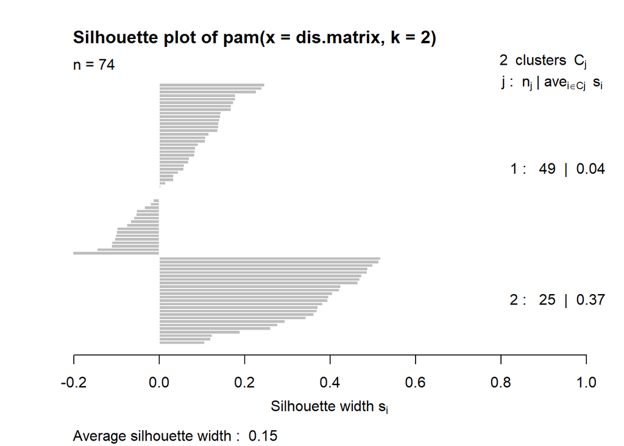

```r
plot(cereals_pam) #Silhouette Plot
```

```r
width_2 <- cereals_pam$silinfo[3] #average width
print(width_2)
```

```
## $avg.width
## [1] 0.1523132
```

For each observation, a silhouette width is calculated. The silhoutte width compares “how close the object is to other objects in its own cluster with how close it is to objects in other clusters” https://www.stat.berkeley.edu/~s133/Cluster2a.html.

Silhouette width is another way of measuring cohesion. We want a value closer to 1 for each cluster. Take a look at the silhouette plot. What do you see? Pretty low values for silhouette width.

Maybe 3 clusters?

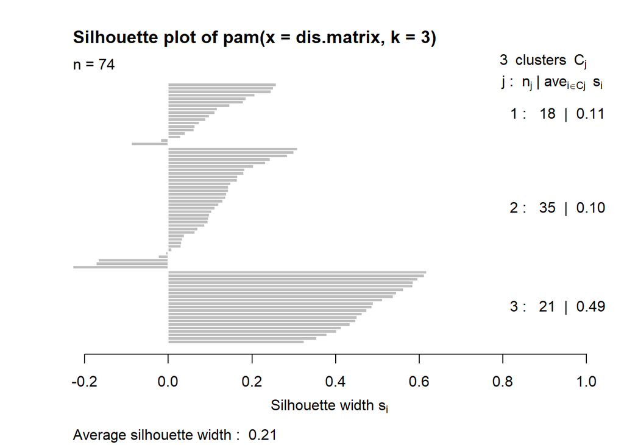

```r
cereals_pam <- pam(dis.matrix, k=3)


plot(cereals_pam) #Silhouette Plot
```

```r
print(cereals_pam$silinfo[3]) #average width
```

```
## $avg.width
## [1] 0.2142152
```

```r
width_3 <- cereals_pam$silinfo[3] #average width
print(width_3)
```

```
## $avg.width
## [1] 0.2142152
```

Better but not really close to 1 - how do we know how many to choose? To estimate the optimal number of clusters, we will use the average silhouette method. The idea is to compute PAM algorithm using different values of clusters k. Next, the average clusters silhouette is drawn according to the number of clusters. The average silhouette measures the quality of a clustering. A high average silhouette width indicates a good clustering. The optimal number of clusters k is the one that maximize the average silhouette over a range of possible values for k.

```r
print(width_2)
```

```
## $avg.width
## [1] 0.1523132
```

```r
print(width_3)
```

```
## $avg.width
## [1] 0.2142152
```

This is a small dataset so we can loop through a few different K’s to see where we get the best silhoutte width:

```r
for(i in 2:10){
 cereals_pam <- pam(dis.matrix, k=i)
 widths <- paste("k = ", i, "width = ", cereals_pam$silinfo[3])
 print(widths)
}
```

```
## [1] "k =  2 width =  0.152313164937641"
## [1] "k =  3 width =  0.214215150413614"
## [1] "k =  4 width =  0.227712658438697"
## [1] "k =  5 width =  0.276090109584189"
## [1] "k =  6 width =  0.280185252903948"
## [1] "k =  7 width =  0.274900921088989"
## [1] "k =  8 width =  0.280979975879355"
## [1] "k =  9 width =  0.291901279319542"
## [1] "k =  10 width =  0.26065051885937"
```

Do we have to go through this every time? No. There is a **pamk** algorithm in the **fpc** package that will choose k for us:

```r
best_pam_cereals <- pamk(cereals_num_z)

best_pam_cereals
```

```
## $pamobject
## Medoids:
##                                  ID   calories    protein        fat
## 100%_Bran                         1 -1.8659155  1.3817478  0.0000000
## Muesli_Raisins,_Dates,_&_Almonds 43  2.1655516  1.3817478  1.9864405
## Clusters                         13  0.1498180  0.4522084  0.9932203
## Trix                             71  0.1498180 -1.4068705  0.0000000
## Basic_4                           7  1.1576848  0.4522084  0.9932203
## Total_Whole_Grain                69 -0.3541153  0.4522084  0.0000000
## Corn_Chex                        15  0.1498180 -0.4773310 -0.9932203
## Shredded_Wheat                   61 -1.3619821 -0.4773310 -0.9932203
## Raisin_Bran                      56  0.6537514  0.4522084  0.0000000
##                                      sodium       fiber      carbo
## 100%_Bran                        -0.3910227  3.22866747 -2.5001396
## Muesli_Raisins,_Dates,_&_Almonds -0.8138823  0.34015322  0.3264071
## Clusters                         -0.2702057 -0.07249167 -0.4444693
## Trix                             -0.2702057 -0.89778146 -0.4444693
## Basic_4                           0.5755136 -0.07249167  0.8403247
## Total_Whole_Grain                 0.4546965  0.34015322  0.3264071
## Corn_Chex                         1.4212328 -0.89778146  1.8681598
## Shredded_Wheat                   -1.9616441  0.34015322  0.3264071
## Raisin_Bran                       0.5755136  1.16544301 -0.1875105
##                                       sugars      potass     weight
## 100%_Bran                        -0.25420505  2.56052289 -0.2008324
## Muesli_Raisins,_Dates,_&_Almonds  0.89281774  1.00857529 -0.2008324
## Clusters                         -0.02480049  0.09151534 -0.2008324
## Trix                              1.12222230 -1.03717383 -0.2008324
## Basic_4                           0.20460407  0.02097226  1.9501886
## Total_Whole_Grain                -0.94241873  0.16205841 -0.2008324
## Corn_Chex                        -0.94241873 -1.03717383 -0.2008324
## Shredded_Wheat                   -1.63063240 -0.04957081 -1.3089342
## Raisin_Bran                       1.12222230  1.99617831  1.9501886
##                                        cups      rating
## 100%_Bran                        -2.0856582  1.85490376
## Muesli_Raisins,_Dates,_&_Almonds  0.7567534 -0.37302488
## Clusters                         -1.3644493 -0.14048876
## Trix                              0.7567534 -1.04166919
## Basic_4                          -0.3038480 -0.38002951
## Total_Whole_Grain                 0.7567534  0.30548275
## Corn_Chex                         0.7567534 -0.06603869
```

[output cut: 150 more lines]

```
##                                      4
## Objective function:
##    build     swap
## 1.689077 1.636543
##
## Available components:
##  [1] "medoids"    "id.med"     "clustering" "objective"  "isolation"
##  [6] "clusinfo"   "silinfo"    "diss"       "call"       "data"
##
## $nc
## [1] 9
##
## $crit
##  [1] 0.0000000 0.1523132 0.2142152 0.2277127 0.2760901 0.2801853 0.2749009
##  [8] 0.2809800 0.2919013 0.2606505
```

Just like with k-means, we can add cluster ID back to each observation.

```r
new_cereals_num <- data.frame(cereals_num,best_pam_cereals$pamobject[3])

head(new_cereals_num[11:12])
```

```
##                             rating clustering
## 100%_Bran                 68.40297          1
## 100%_Natural_Bran         33.98368          2
## All-Bran                  59.42551          1
## All-Bran_with_Extra_Fiber 93.70491          1
## Apple_Cinnamon_Cheerios   29.50954          3
## Apple_Jacks               33.17409          4
```